# BEES3041 Canopy Height

Gillian

03/08/2021

# **Study Aim:**

To investigate the bimodality in canopy height distribution in the intermediate rainfall zone (1500-2000mm).

## **Examine the role of:**

- Human disturbance
- Biome classification
- Fire size

## **Data Processing**

**Load libraries**

```r
library(tidyverse)
library(png)
library(raster)
library(rgdal)
library(ncdf4)
library(sf)
library(sp)
library(readxl)
```

*Source data proccessing file with precreated functions to load the datasets*

```r
source("R/data_processing.R")
```

**Loading data and creating a combined dataframe:**

```r
data_height <- get_height_df()

data_precip <- get_precip_df()

data_treecover <- get_tree_cover_df()

data_globcover <- get_area_type_df()

data_intactforest <- get_intactforest_df()

data_all <-
  init_globe_df() %>%
  left_join(by = c("x", "y"), data_height) %>%
  left_join(by = c("x", "y"), data_precip) %>%
  left_join(by = c("x", "y"), data_treecover) %>%
  left_join(by = c("x", "y"), data_globcover) %>%
  left_join(by = c("x", "y"), data_intactforest) %>%
  mutate(forest_zone = percentage_tree_cover >= 20)

saveRDS(data_all, "data/data_all.rds")
```

```r
data_all <- readRDS("data/data_all.rds")
```

**Subsetting Data to only include only areas with >20% vegetation cover and with a ‘forest’ biome classification and in rainfall zone 1500-2000mm.**

```r
data_all_graphing <-
  subset(data_all,
         canopy_height > 1 &
           percentage_tree_cover > 0.001 & forest_zone == "TRUE")

data_subset_graphing <-
  subset(
    data_all_graphing,
    forest_zone == "TRUE" &
      globcover_numeric != "11" &
      globcover_numeric != "14" &
      globcover_numeric != "20" &
      globcover_numeric != "30" &
      globcover_numeric != "190" &
      globcover_numeric != "200" &
      globcover_numeric != "210" &
      globcover_numeric != "220" &
      globcover_numeric != "230" &
      globcover_numeric != "150" &
      !is.na(data_all_graphing$globcover_numeric)
  )

rain_gap <-
  data_subset_graphing %>% filter(mean_annual_precipitation < 2000) %>%
  filter(mean_annual_precipitation > 1500)
```

## **Visualising Data**

**Precipitation count graphs for all data and subset data:**

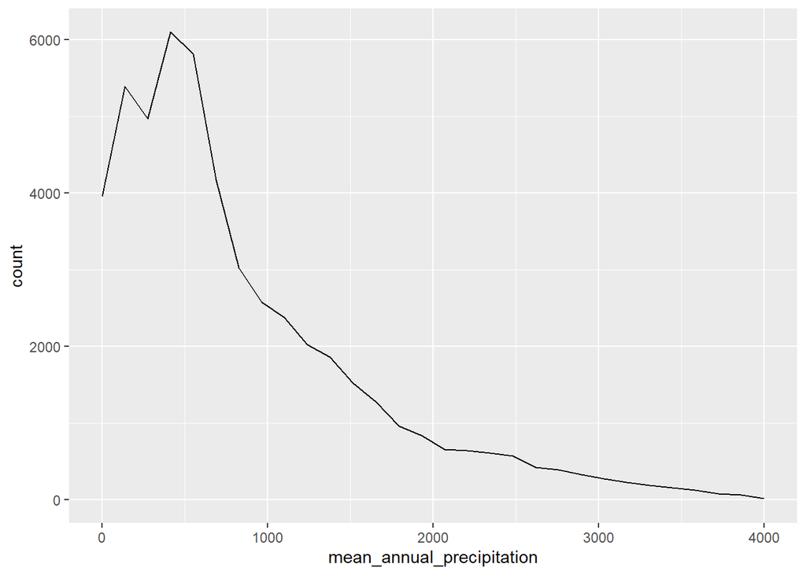

```r
# Count for all data
ggplot(data_all, aes(mean_annual_precipitation)) +
  geom_freqpoly(stat = "bin") +
  scale_x_continuous(limits = c(0, 4000))
```

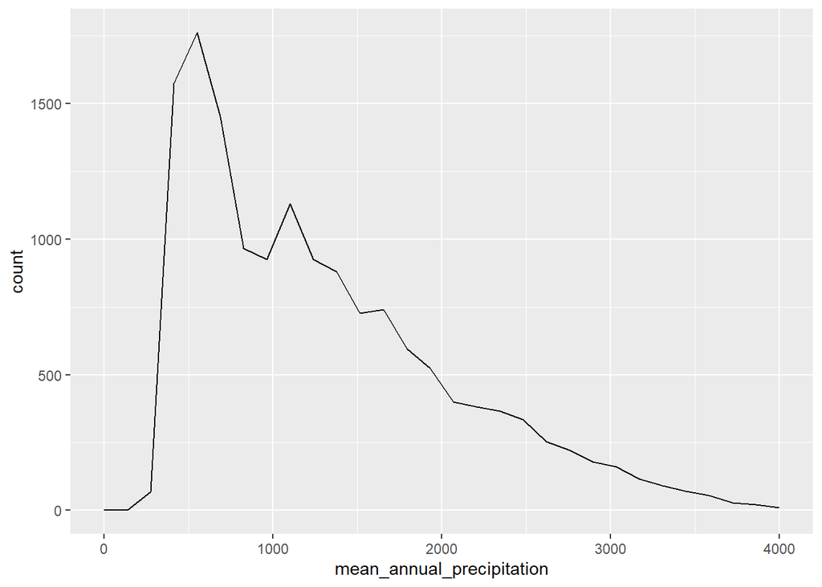

```r
# Count for forest subsetted data
ggplot(data_subset_graphing, aes(mean_annual_precipitation)) +
  geom_freqpoly(stat = "bin") +
  scale_x_continuous(limits = c(0, 4000))
```

**Visualizing intactness and canopy height Data through recreating Scheffer et al (2018) and Falster et al (unpublished)’s graphs.**

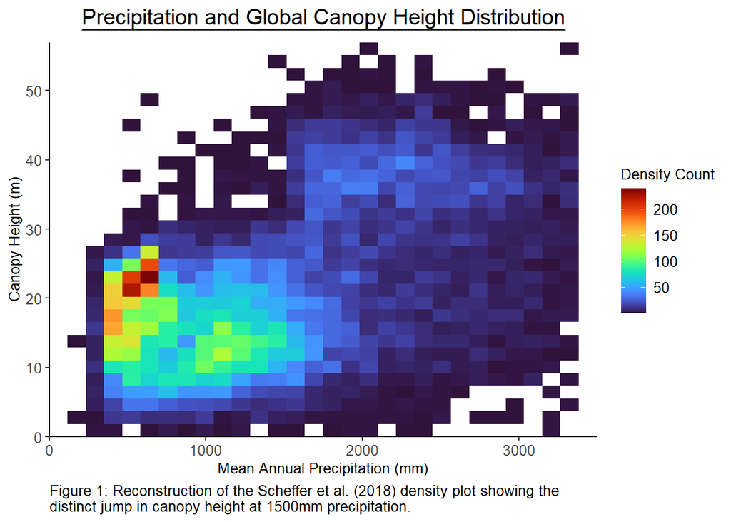

```r
library(ggplot2)
library(tidyverse)
library(viridis)
#Recreating Scheffer et al (2018) density plot

ggplot(data_subset_graphing,
       aes(mean_annual_precipitation, canopy_height)) +
  geom_bin2d() +
  scale_fill_viridis(option = "turbo") +
  scale_x_continuous(expand = c(0, 0), limit = c(0, 3500)) +
  scale_y_continuous(expand = c(0, 0)) +
  theme_classic() + ggtitle(expression(
    underline("Precipitation and Global Canopy Height Distribution")
  )) + labs(y = "Canopy Height (m)", x = "Mean Annual Precipitation (mm)", caption = "Figure 1: Reconstruction of the Scheffer et al. (2018) density plot showing the \ndistinct jump in canopy height at 1500mm precipitation.") + labs(fill = "Density Count") + theme(
    plot.title = element_text(hjust = 0.5, size = 15, face = "bold"),
    plot.caption = element_text(hjust = 0, size = 10),
    axis.text = element_text(size = 10),
    axis.title = element_text(size = 10),
    legend.text = element_text(size = 10),
    legend.title = element_text(size = 10)
  )
```

```r
ggsave("recreation_scheffer.png",
       width = 10,
       height = 6,
)
```

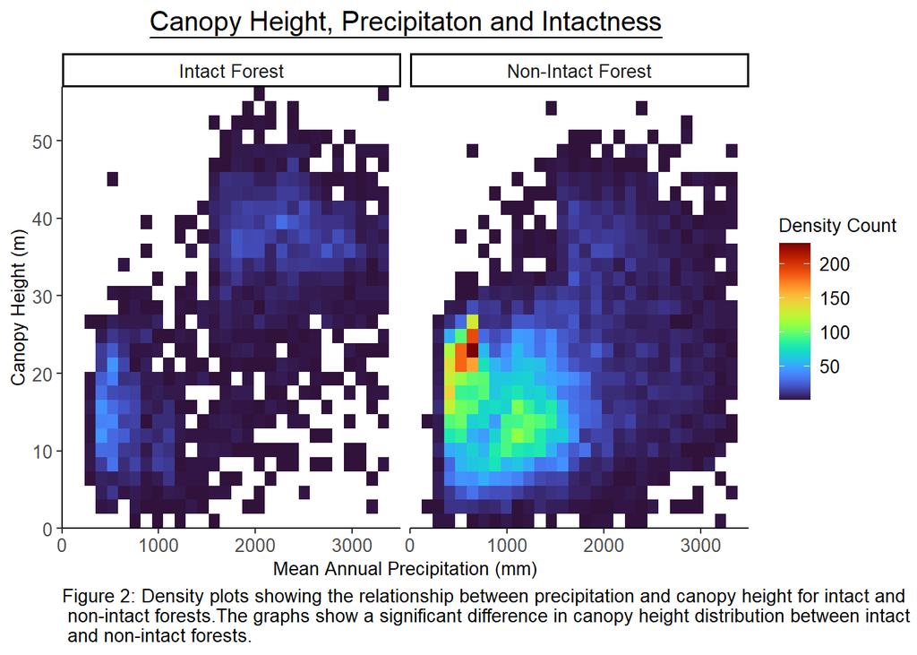

```r
#Recreating Falster et al (unpublished) density plot separating intact vs non intact

ggplot(data_subset_graphing,
       aes(mean_annual_precipitation, canopy_height)) +
  geom_bin2d() + scale_fill_viridis(option = "turbo") + facet_wrap( ~ intact_forest) + scale_x_continuous(expand = c(0, 0), limits = c(0, 3500)) +
  scale_y_continuous(expand = c(0, 0)) +
  theme_classic() +
  theme_classic() + ggtitle(expression(underline(
    "Canopy Height, Precipitaton and Intactness"
  ))) + labs(y = "Canopy Height (m)", x = "Mean Annual Precipitation (mm)", caption = "Figure 2: Density plots showing the relationship between precipitation and canopy height for intact and\n non-intact forests.The graphs show a significant difference in canopy height distribution between intact\n and non-intact forests.") + labs(fill = "Density Count") + theme(
    plot.title = element_text(hjust = 0.5, size = 15, face = "bold"),
    plot.caption = element_text(hjust = 0, size = 10),
    axis.text = element_text(size = 10),
    axis.title = element_text(size = 10),
    legend.text = element_text(size = 10),
    legend.title = element_text(size = 10),
    strip.text = element_text(size = 10)
  )
```

```r
ggsave("recreation_falsterintactnon.png",
       width = 10,
       height = 6,
)
```

**Investigating If Land Cover Classification Could Have A Relationship with Canopy Height.** *Decided not to further investigate*

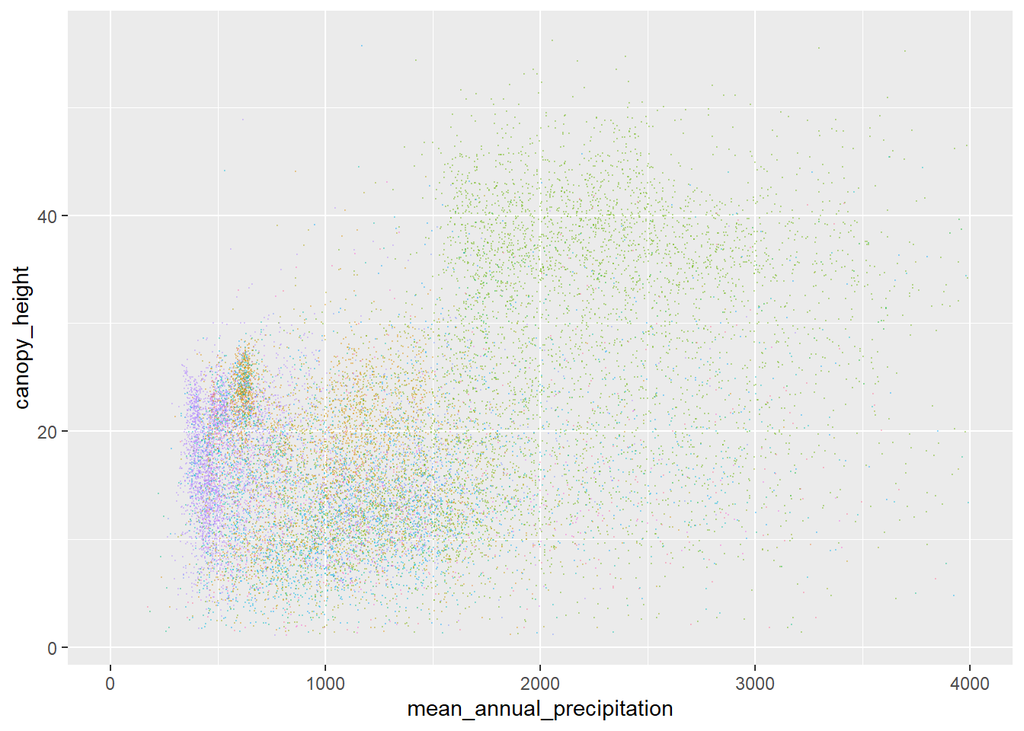

```r
ggplot(data_all_graphing,
       aes(mean_annual_precipitation, canopy_height)) +
  geom_point(size = 0.05,
             alpha = 0.3,
             aes(colour = globcover_label)) +
  scale_x_continuous(limits = c(0, 4000)) + theme(legend.position = "none")
```

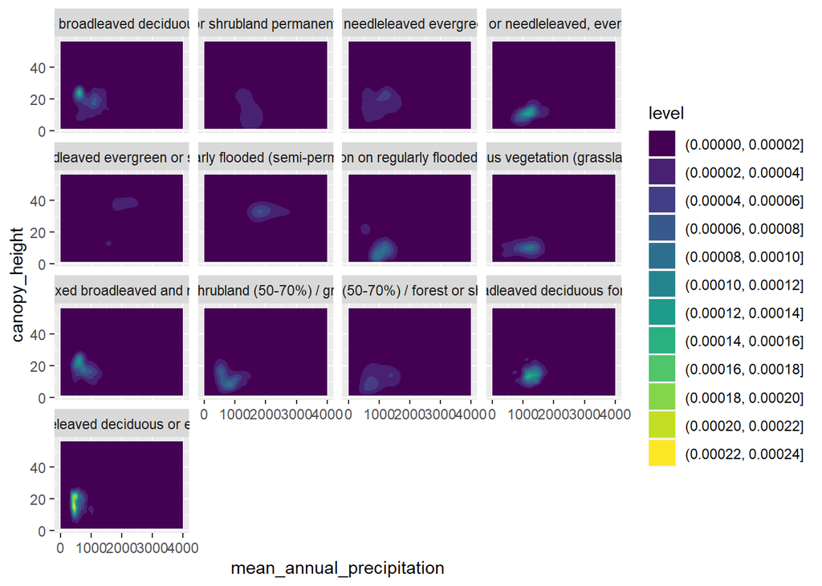

```r
## removing pesky "NA" values
is.na_remove <- subset(data_subset_graphing,!is.na(data_subset_graphing$globcover_label))

ggplot(is.na_remove, aes(mean_annual_precipitation, canopy_height)) +
  scale_x_continuous(limits = c(0, 4000)) +
  geom_density_2d_filled() +
  facet_wrap(vars(globcover_label))
```

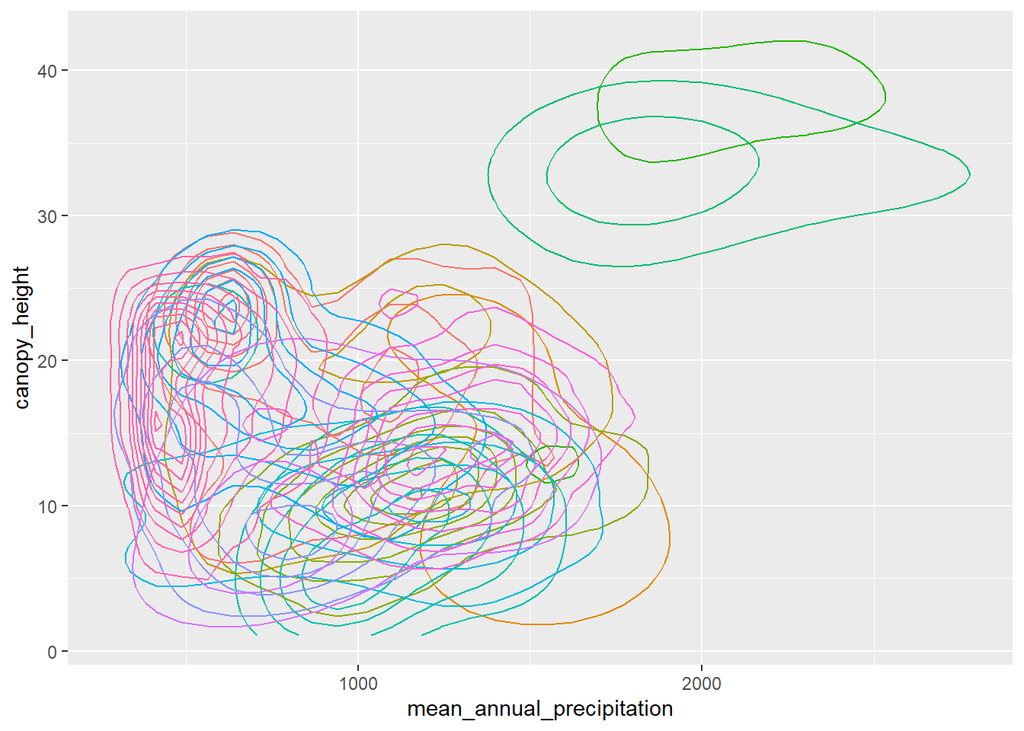

```r
#graphing biomes
ggplot(is.na_remove, aes(mean_annual_precipitation, canopy_height)) +
  geom_density_2d(aes(colour = globcover_label)) + theme(legend.position = "none")
```

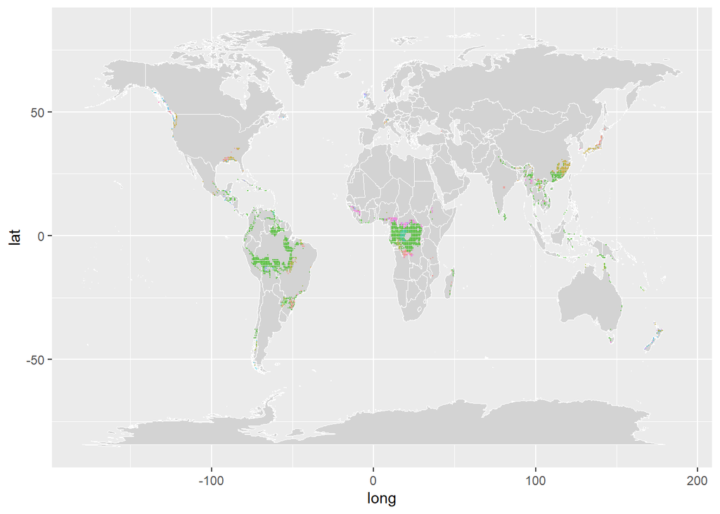

```r
# Map to show distribution of biomes
world <- map_data("world")

ggplot() +
  geom_map(
    data = world,
    map = world,
    aes(long, lat, map_id = region),
    color = "white",
    fill = "lightgray",
    size = 0.1
  ) +
  geom_point(
    data = rain_gap,
    aes(x, y, colour = globcover_label),
    alpha = 0.4,
    size = 0.1
  ) + theme(legend.position = "none") #remove legend expression to see legend
```

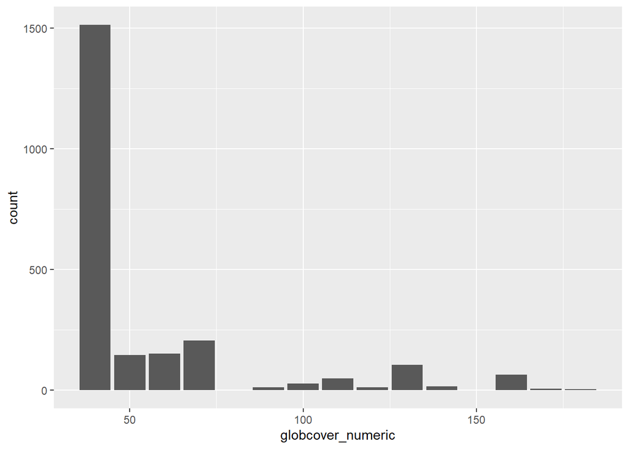

```r
#Frequency Distribution of biomes in 1500-2000mm rainfall zone
ggplot(rain_gap, aes(globcover_numeric)) +
  geom_histogram(stat = "count")
```

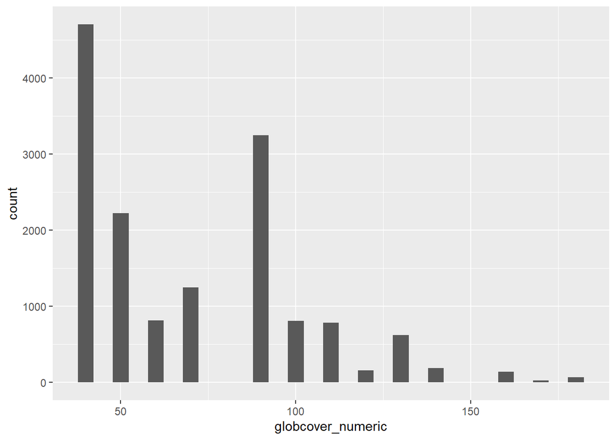

```r
#Frequency Distribution of biomes for all rainfall zones
ggplot(data_subset_graphing, aes(globcover_numeric)) +
  geom_histogram(stat = "count")
```

**Mapping canopy height and intactness to visualise global patterns in distribution:**

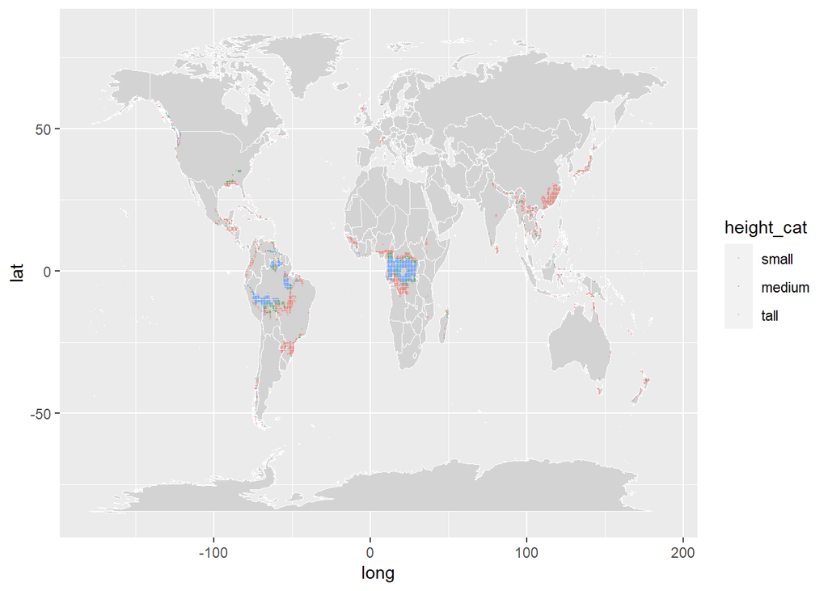

```r
## turning height into a categorical variable (0-25=small 25-30=medium 30-> tall)
height_cat <-
  cut (
    rain_gap$canopy_height,
    breaks = c(0, 25, 30, 60),
    labels = c("small", "medium", "tall")
  )
rain_gap$height_cat <- height_cat


##Mapping the global distribution of canopy height categories
world <- map_data("world")

ggplot() +
  geom_map(
    data = world,
    map = world,
    aes(long, lat, map_id = region),
    color = "white",
    fill = "lightgray",
    size = 0.1
  ) +
  geom_point(
    data = rain_gap,
    aes(x, y, colour = height_cat),
    alpha = 0.4,
    size = 0.1
  )
```

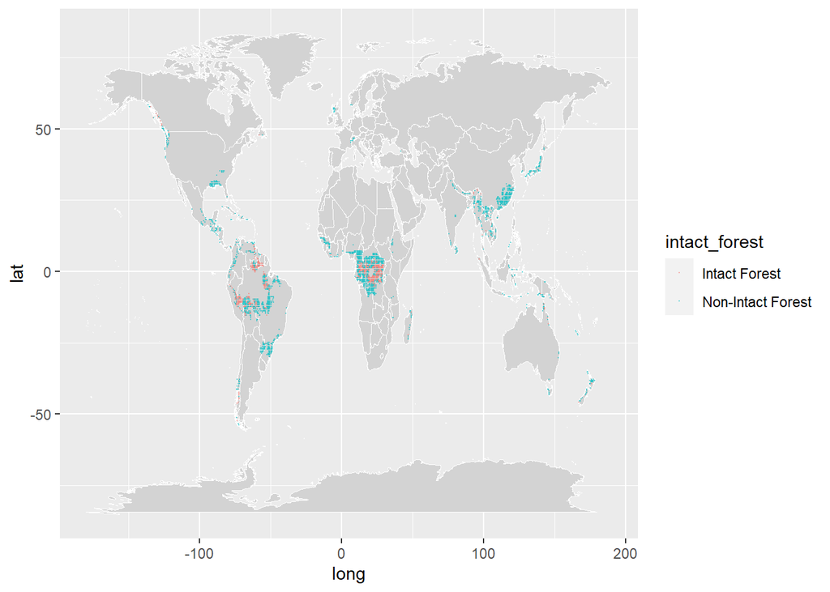

```r
## Mapping the distribution of intact and non-intact forests
ggplot() +
  geom_map(
    data = world,
    map = world,
    aes(long, lat, map_id = region),
    color = "white",
    fill = "lightgray",
    size = 0.1
  ) +
  geom_point(
    data = rain_gap,
    aes(x, y, colour = intact_forest),
    alpha = 0.4,
    size = 0.1
  )
```

## **Data Processing**

**Loading Fire Data to Help Explain Canopy Bimodality**

```r
load_fire <- function(year) {
  path <- paste0("data/firedata/", year, "firesize.tif")

  e <- set_extent()

  raster::stack(path) %>%
    sum() %>%
    crop(e) %>%
    raster::as.data.frame(xy = TRUE) %>%
    as_tibble() %>%
    mutate(year = year)
}

## (run in analysis for file location)

fire_2003 <- load_fire(2003)
fire_2004 <- load_fire(2004)
fire_2005 <- load_fire(2005)
fire_2006 <- load_fire(2006)
fire_2007 <- load_fire(2007)
fire_2008 <- load_fire(2008)
fire_2009 <- load_fire(2009)
fire_2010 <- load_fire(2010)
fire_2011 <- load_fire(2011)
fire_2012 <- load_fire(2012)
fire_2013 <- load_fire(2013)
fire_2014 <- load_fire(2014)
fire_2015 <- load_fire(2015)
fire_2016 <- load_fire(2016)

#Joining yearly fire Data into a single dataframe

all_fire <-
  rbind(
    fire_2003,
    fire_2004,
    fire_2005,
    fire_2006,
    fire_2007,
    fire_2008,
    fire_2009,
    fire_2010,
    fire_2011,
    fire_2012,
    fire_2013,
    fire_2014,
    fire_2015,
    fire_2016
  )

#Calculating total burnt area and mean burnt area

fire_sum <-
  all_fire %>% group_by(x, y) %>% summarise(total_burnt_area = sum(layer))
fire_average <-
  all_fire %>% group_by(x, y) %>% summarise(mean_burnt_area = mean(layer))
```

Changing the downscale function:

```r
downscale_spatial_data_.5 <- function(rl, func = "mean") {
  cells.per.degree <- rl@ncols / (xmax(extent(rl) - 1) - xmin(extent(rl) -
                                                                1))
  factor <- cells.per.degree / 2

  # perform downscale and return resultant RasterLayer
  if (factor > 1)
    rl <- aggregate(rl,
                    fact = factor,
                    fun = func)
  rl
}
```

Rescaling the sum and average columns:

```r
#fire sum rescale
coordinates(fire_sum) <- ~ x + y
gridded(fire_sum) <- TRUE
raster_sum_fire <- raster(fire_sum)

rescale_sum_fire <- downscale_spatial_data_.5(raster_sum_fire)

e <- set_extent()

rescale_sum_fire <- raster::stack(rescale_sum_fire) %>%
  sum() %>%
  crop(e) %>%
  raster::as.data.frame(xy = TRUE) %>%
  as_tibble()
#fire average rescale
coordinates(fire_average) <- ~ x + y
gridded(fire_average) <- TRUE
raster_average_fire <- raster(fire_average)

rescale_average_fire <-
  downscale_spatial_data_.5(raster_average_fire)

e <- set_extent()

rescale_average_fire <- raster::stack(rescale_average_fire) %>%
  sum() %>%
  crop(e) %>%
  raster::as.data.frame(xy = TRUE) %>%
  as_tibble()
```

**Joining the fire data with the rest of the data:**

```r
data_all_withfire <-
  data_all %>%
  left_join(by = c("x", "y"), rescale_sum_fire)

data_all_withfire <-
  data_all_withfire %>%
  left_join(by = c("x", "y"), rescale_average_fire)

data_all_withfire_graphing <-
  subset(
    data_all_withfire,
    canopy_height > 1 &
      percentage_tree_cover > 0.001 & forest_zone == "TRUE"
  )

data_subset_withfire_graphing <-
  subset(
    data_all_withfire_graphing,
    forest_zone == "TRUE" &
      globcover_numeric != "11" &
      globcover_numeric != "14" &
      globcover_numeric != "20" &
      globcover_numeric != "30" &
      globcover_numeric != "190" &
      globcover_numeric != "200" &
      globcover_numeric != "210" &
      globcover_numeric != "220" &
      globcover_numeric != "230" &
      globcover_numeric != "150" &
      !is.na(data_all_withfire_graphing$globcover_numeric)
  )

#Creating dataframe that includes fire just for the Intermediate Rainfall Zone

rain_gap_fire <-
  data_subset_withfire_graphing %>% filter(mean_annual_precipitation < 2000) %>%
  filter(mean_annual_precipitation > 1500)
```

## **Visualising Data**

**Graphing the raw fire data to understand its distribution.**

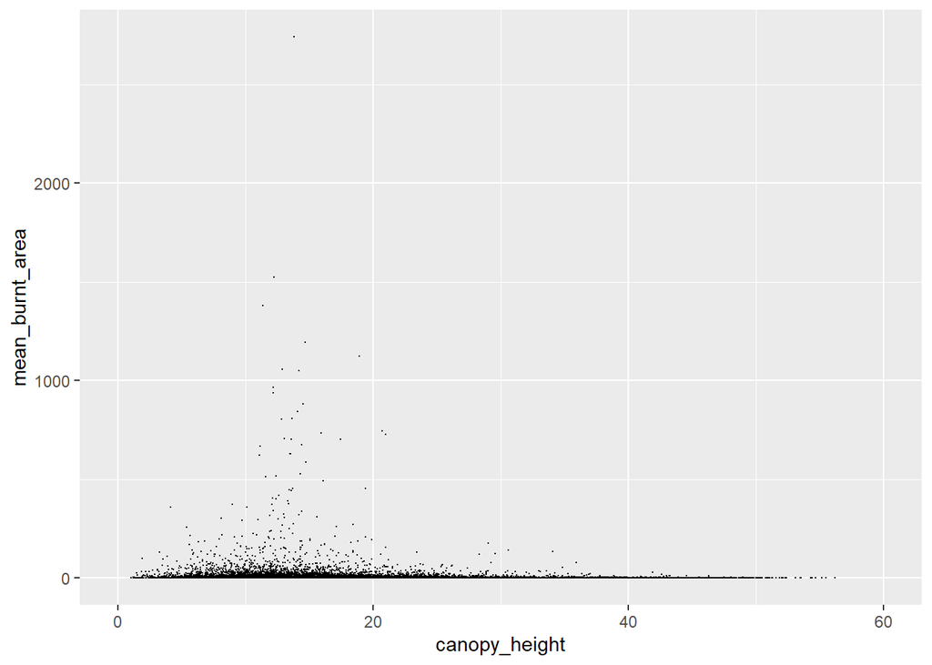

```r
#Visualising the mean annual fire size and total fire size in relation to canopy height and precipitation

ggplot(data_subset_withfire_graphing, aes(canopy_height, mean_burnt_area)) +
  geom_point(size=0.05) +
  scale_x_continuous(limits = c(0, 60))
```

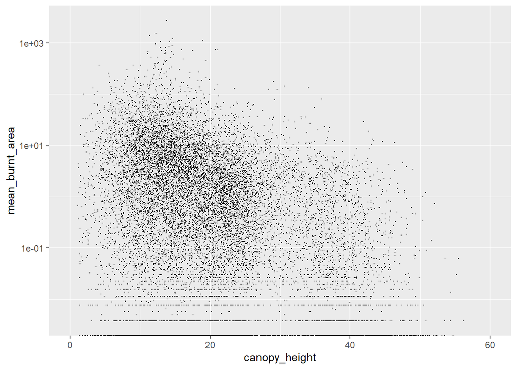

```r
ggplot(data_subset_withfire_graphing, aes(canopy_height, mean_burnt_area)) +
  geom_point(size=0.05) +
  scale_x_continuous(limits = c(0, 60)) + scale_y_log10()
```

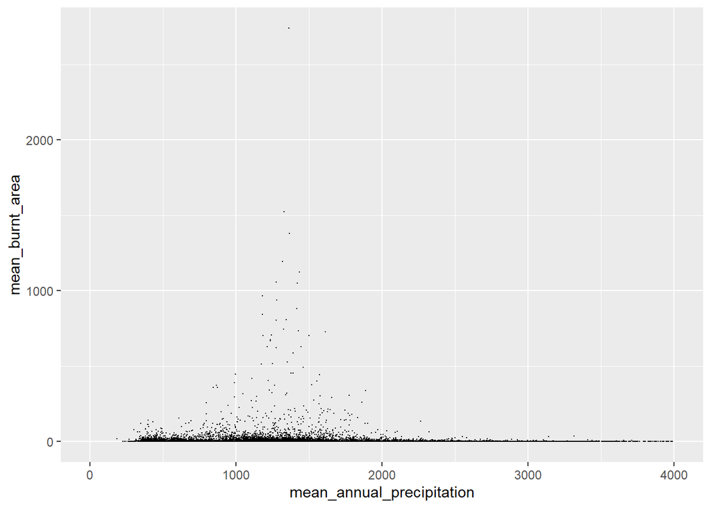

```r
ggplot(data_subset_withfire_graphing, aes(mean_annual_precipitation, mean_burnt_area)) +
  geom_point(size=0.05) +
  scale_x_continuous(limits = c(0, 4000))
```

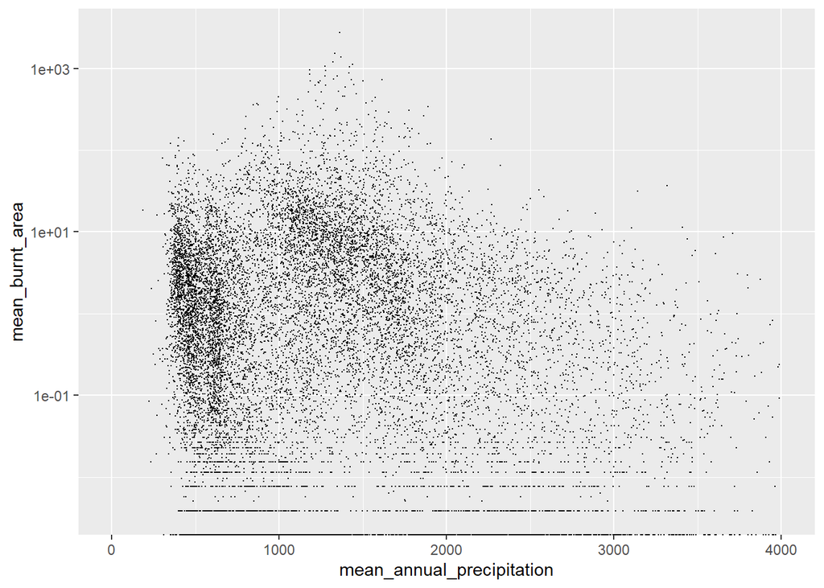

```r
ggplot(data_subset_withfire_graphing, aes(mean_annual_precipitation, mean_burnt_area)) +
  geom_point(size=0.05) +
  scale_x_continuous(limits = c(0, 4000)) + scale_y_log10()
```

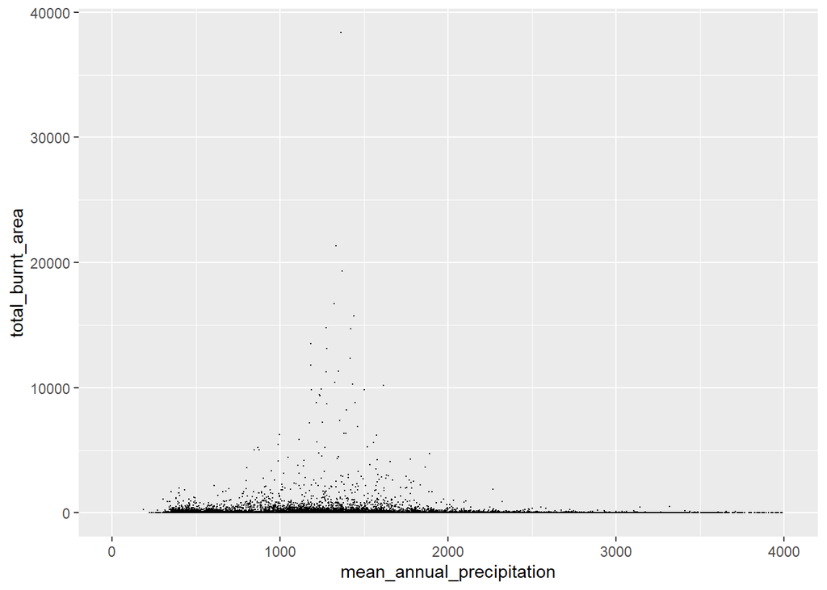

```r
ggplot(data_subset_withfire_graphing, aes(mean_annual_precipitation, total_burnt_area)) +
  geom_point(size=0.05) +
  scale_x_continuous(limits = c(0, 4000))
```

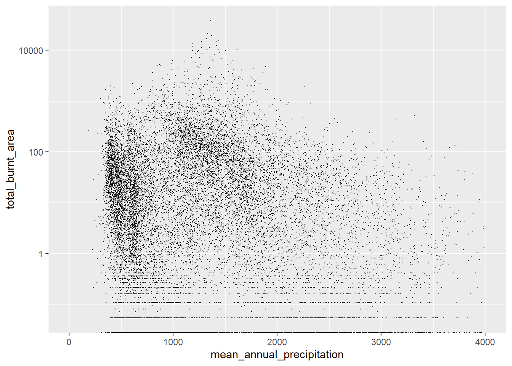

```r
ggplot(data_subset_withfire_graphing, aes(mean_annual_precipitation, total_burnt_area)) +
  geom_point(size=0.05) +
  scale_x_continuous(limits = c(0, 4000)) + scale_y_log10()
```

**Visualising the interaction between variables.**

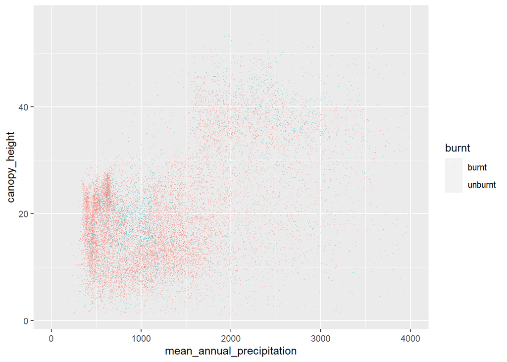

```r
#Creating a burnt column for fire data to record areas a fire has passed through
data_subset_withfire_graphing$burnt <- if_else(data_subset_withfire_graphing$mean_burnt_area > 0, "burnt", "unburnt")


#graphing the relationship between canopy height and preciptiation and colouring by burnt or unburnt
ggplot(data_subset_withfire_graphing, aes(mean_annual_precipitation, canopy_height )) +
  geom_point(size=0.05, alpha=0.3, aes(colour=burnt)) +
  scale_x_continuous(limits = c(0, 4000))
```

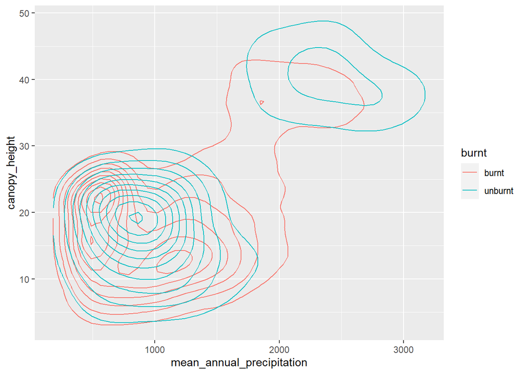

```r
#graph showing burnt area and canopy height relationship
ggplot(data_subset_withfire_graphing, aes(mean_annual_precipitation, canopy_height )) +
   geom_density_2d(aes(colour = burnt))
```

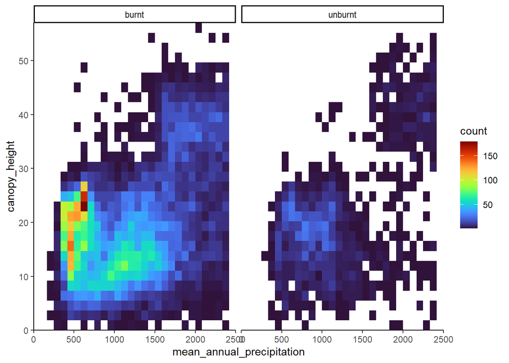

```r
ggplot(data_subset_withfire_graphing, aes(mean_annual_precipitation, canopy_height)) +
  geom_bin2d()+ scale_fill_viridis(option = "turbo") + facet_wrap(~burnt)+ scale_y_continuous(expand = c(0, 0)) +
  scale_x_continuous(expand = c(0, 0), limit = c(0, 2500)) +
  theme_classic()
```

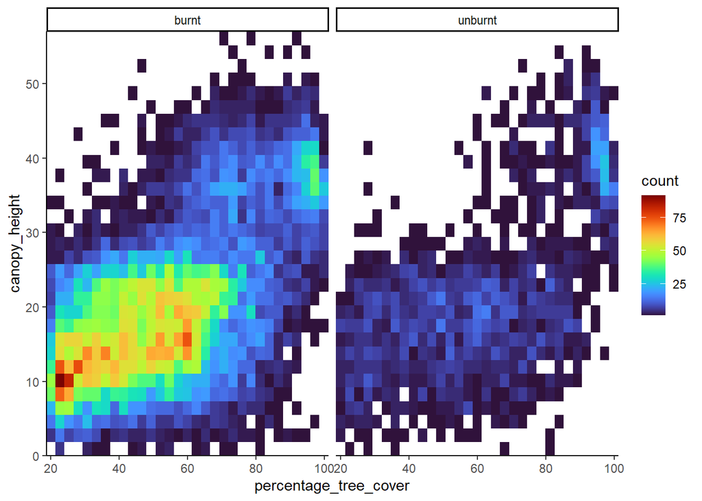

```r
#burnt vs unburnt for canopy height/cover
ggplot(data_subset_withfire_graphing, aes(percentage_tree_cover, canopy_height)) +
  geom_bin2d()+ scale_fill_viridis(option = "turbo") + facet_wrap(~burnt)+ scale_x_continuous(expand = c(0, 0)) +
  scale_y_continuous(expand = c(0, 0)) +
  theme_classic()
```

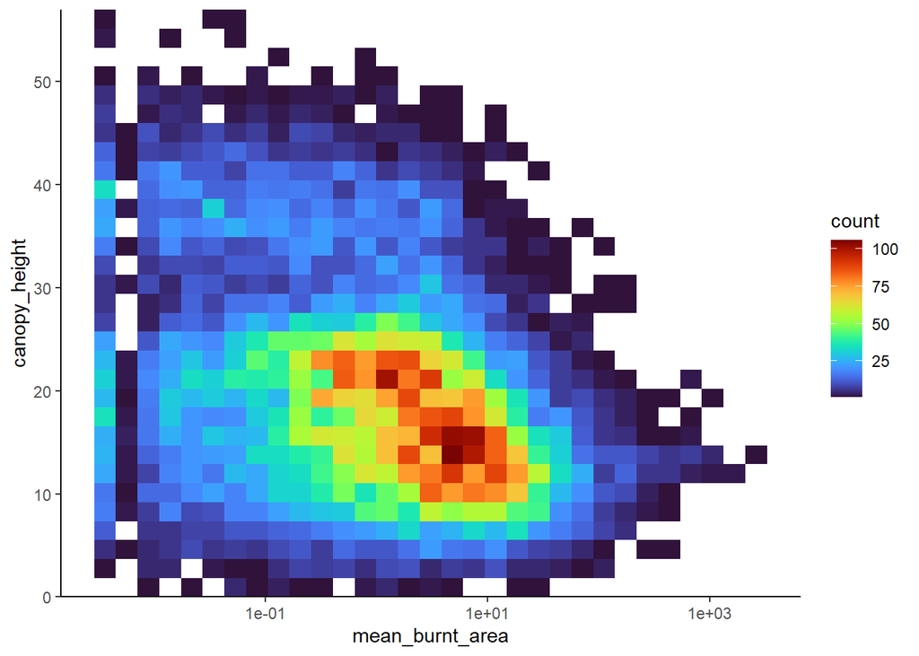

```r
#Density plot burnt area and canopy height
ggplot(data_subset_withfire_graphing, aes(mean_burnt_area, canopy_height)) +
  geom_bin2d()+
  scale_fill_viridis(option = "turbo")+
  scale_x_continuous(expand = c(0, 0), limit = c(0, 1000)) +
  scale_y_continuous(expand = c(0, 0)) +
  theme_classic() + scale_x_log10()
```

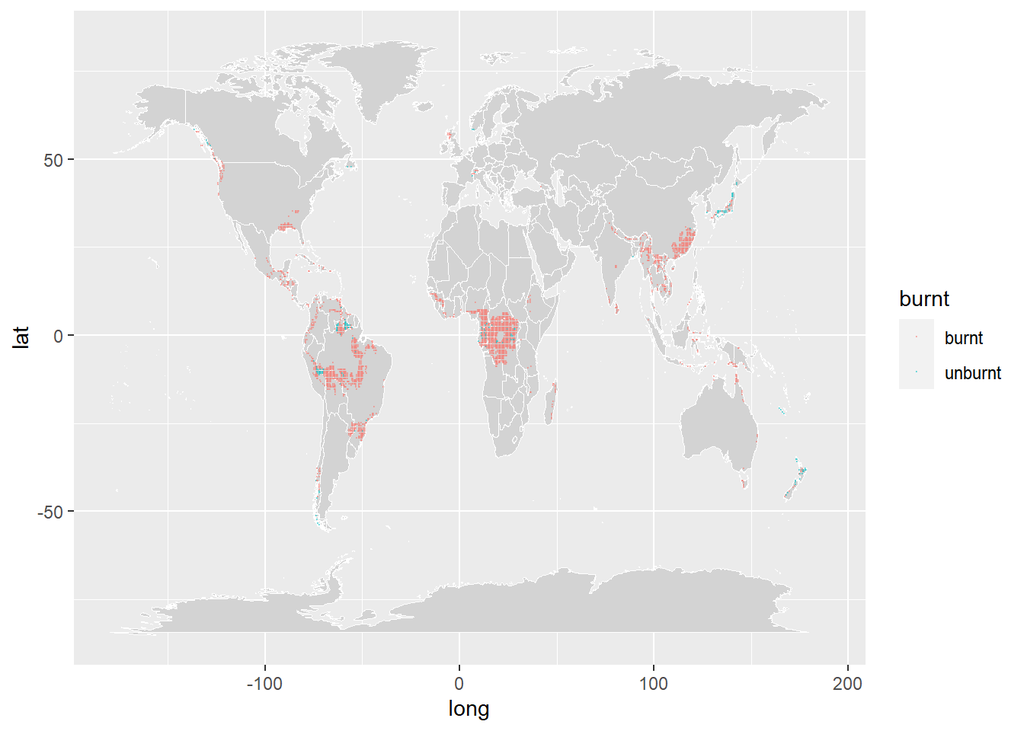

```r
#Mapping burnt and unburnt areas in rainfall zone 1500-200mm, showing most areas have been burnt
fire_distribution_rainfallzone <- data_subset_withfire_graphing %>% filter(mean_annual_precipitation < 2000, mean_annual_precipitation > 1500)

ggplot() +
  geom_map(
    data = world, map = world,
    aes(long, lat, map_id = region),
    color = "white", fill = "lightgray", size = 0.1
    ) +
  geom_point(
    data = fire_distribution_rainfallzone,
    aes(x, y, colour=burnt),
    alpha = 0.4, size = 0.1
  )
```

**Graphing the effect of fire and intactness on canopy height:**

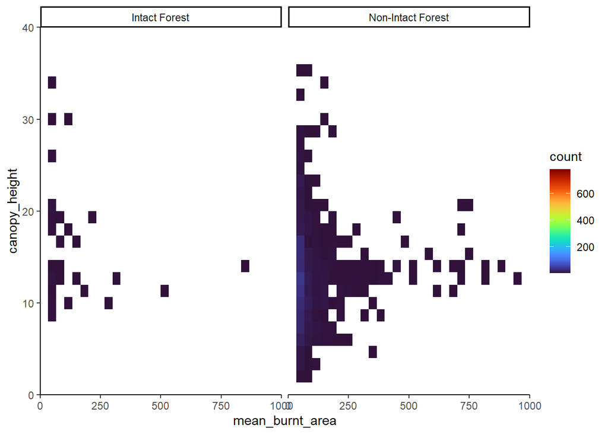

```r
#mean burnt area and canopy height by intact vs non intact
ggplot(data_subset_withfire_graphing, aes(mean_burnt_area, canopy_height)) +
  geom_bin2d()+ scale_fill_viridis(option = "turbo") + facet_wrap(~intact_forest)+ scale_x_continuous(expand = c(0, 0)) +
  scale_y_continuous(expand = c(0, 0)) +
  theme_classic() + scale_x_continuous(expand = c(0, 0), limit= c(0, 1000)) +
  scale_y_continuous(expand = c(0, 0), limit = c(0, 40)) +
  theme_classic()
```

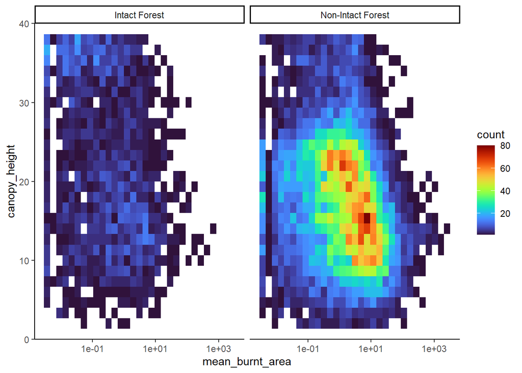

```r
ggplot(data_subset_withfire_graphing, aes(mean_burnt_area, canopy_height)) +
  geom_bin2d()+ scale_fill_viridis(option = "turbo") + facet_wrap(~intact_forest)+ scale_x_continuous(expand = c(0, 0)) +
  scale_y_continuous(expand = c(0, 0)) +
  theme_classic() + scale_x_continuous(expand = c(0, 0), limit= c(0, 1000)) +
  scale_y_continuous(expand = c(0, 0), limit = c(0, 40)) +
  theme_classic() + scale_x_log10()
```

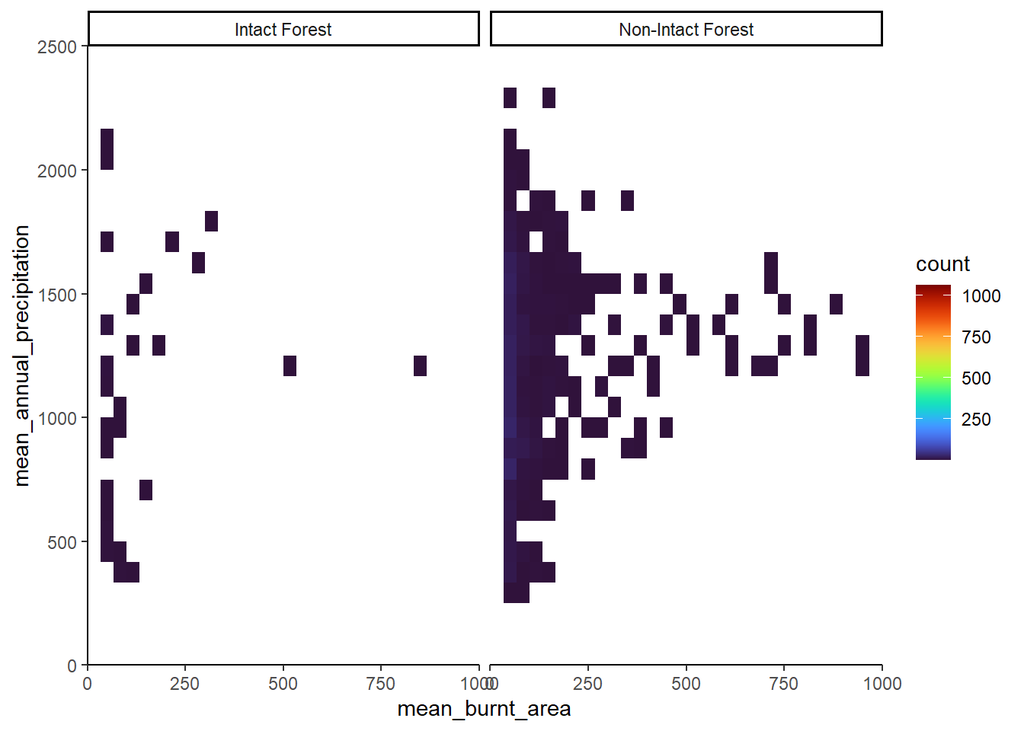

```r
ggplot(data_subset_withfire_graphing, aes(mean_burnt_area, mean_annual_precipitation)) +
  geom_bin2d()+ scale_fill_viridis(option = "turbo") + facet_wrap(~intact_forest)+ scale_x_continuous(expand = c(0, 0)) +
  scale_y_continuous(expand = c(0, 0)) +
  theme_classic() + scale_x_continuous(expand = c(0, 0), limit= c(0, 1000)) +
  scale_y_continuous(expand = c(0, 0), limit = c(0, 2500)) +
  theme_classic()
```

**Creating a new variable of big fire or little/no fire because most cells had some level of burnt.**

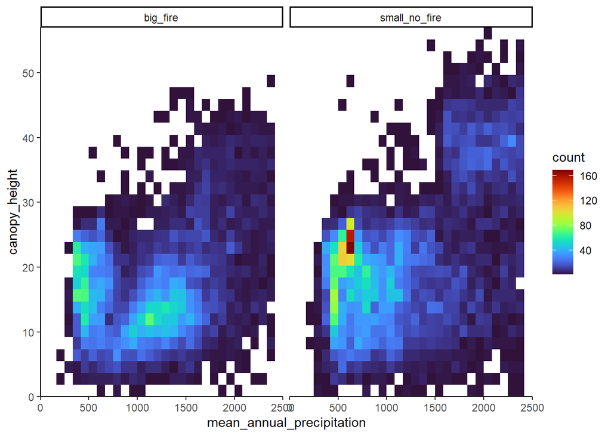

```r
#Dividing fire data into big and small/no fire categories

data_subset_withfire_graphing$firesize <- if_else(data_subset_withfire_graphing$mean_burnt_area > 1.25, "big_fire", "small_no_fire")

rain_gap_fire$firesize <- if_else(rain_gap_fire$mean_burnt_area > 1.25, "big_fire", "small_no_fire")


#Comparing use of burnt and unburnt values with new values that divide by big and small fire

ggplot(data_subset_withfire_graphing, aes(mean_annual_precipitation, canopy_height)) +
  geom_bin2d()+ scale_fill_viridis(option = "turbo") + facet_wrap(~firesize)+ scale_y_continuous(expand = c(0, 0)) +
  scale_x_continuous(expand = c(0, 0), limit = c(0, 2500)) +
  theme_classic()
```

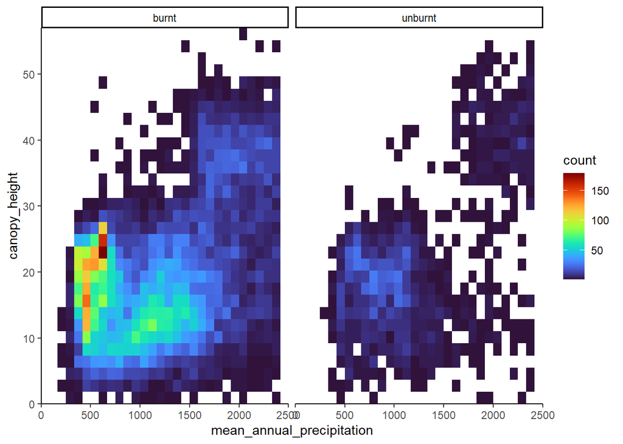

```r
ggplot(data_subset_withfire_graphing, aes(mean_annual_precipitation, canopy_height)) +
  geom_bin2d()+ scale_fill_viridis(option = "turbo") + facet_wrap(~burnt)+ scale_y_continuous(expand = c(0, 0)) +
  scale_x_continuous(expand = c(0, 0), limit = c(0, 2500)) +
  theme_classic()
```

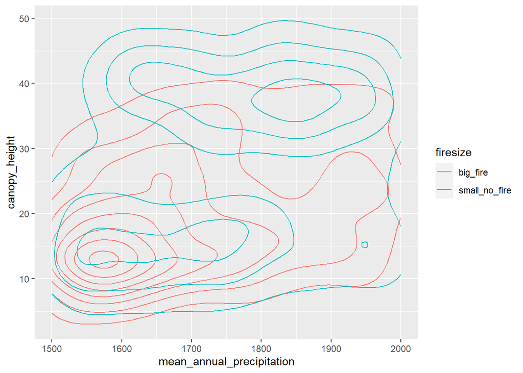

```r
ggplot(rain_gap_fire, aes(mean_annual_precipitation, canopy_height )) +
       geom_density_2d(aes(colour = firesize))
```

**Looking at interaction between precipitation, fire, intactness and canopy height**

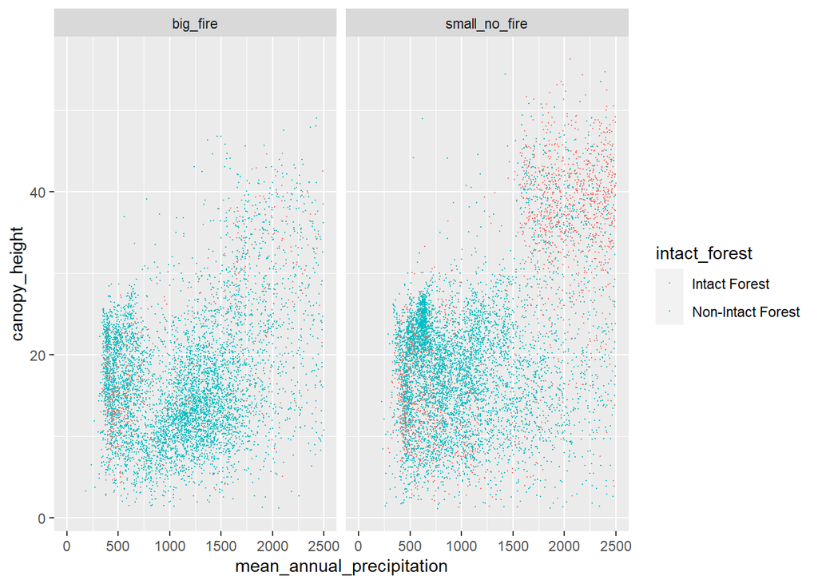

```r
ggplot(data_subset_withfire_graphing, aes(mean_annual_precipitation, canopy_height)) +
  geom_point(size=0.05, aes(colour=intact_forest)) +  scale_x_continuous(limit = c(0, 2500)) + facet_wrap(~firesize)
```